# IODS course project

Kimmo Kallonen

# Introduction to Open Data Science - Course Project

# About the project

This is the course diary for the Introduction to Open Data Science course at University of Helsinki. This MOOC course covers statistical concepts, which will be useful to my work as a PhD student. I’m looking forward to many interesting exercises!

Click [here](https://github.com/kimmokal/IODS-project) to go to the GitHub repository for this diary.

# Week 2: Regression and model validation

A data set, which contains answers from a survey conducted among students on an introductory statistics course, was examined.

There are 183 subjects, and the number reduces to 166 after excluding those who didn’t attend the final exam of the course. For each subject, there are 60 features, of which 56 are answers to survey questions. The other four are *gender*, *age*, *points* from the exam, and finally *attitude*, which is a summary variable from certain answers to the survey.

The questions in the survey pertained to the students’ attitude and approaches to learning. The three distinguish learning approaches were defined as surface level, deep level and strategic level. The 56 survey questions were condensed to these 3 variables (named *surf*, *deep*, *stra*), so in the end there are 7 features for each student.

### Graphical overview of the data

Let’s see how the variables in the data look and compare to each other.

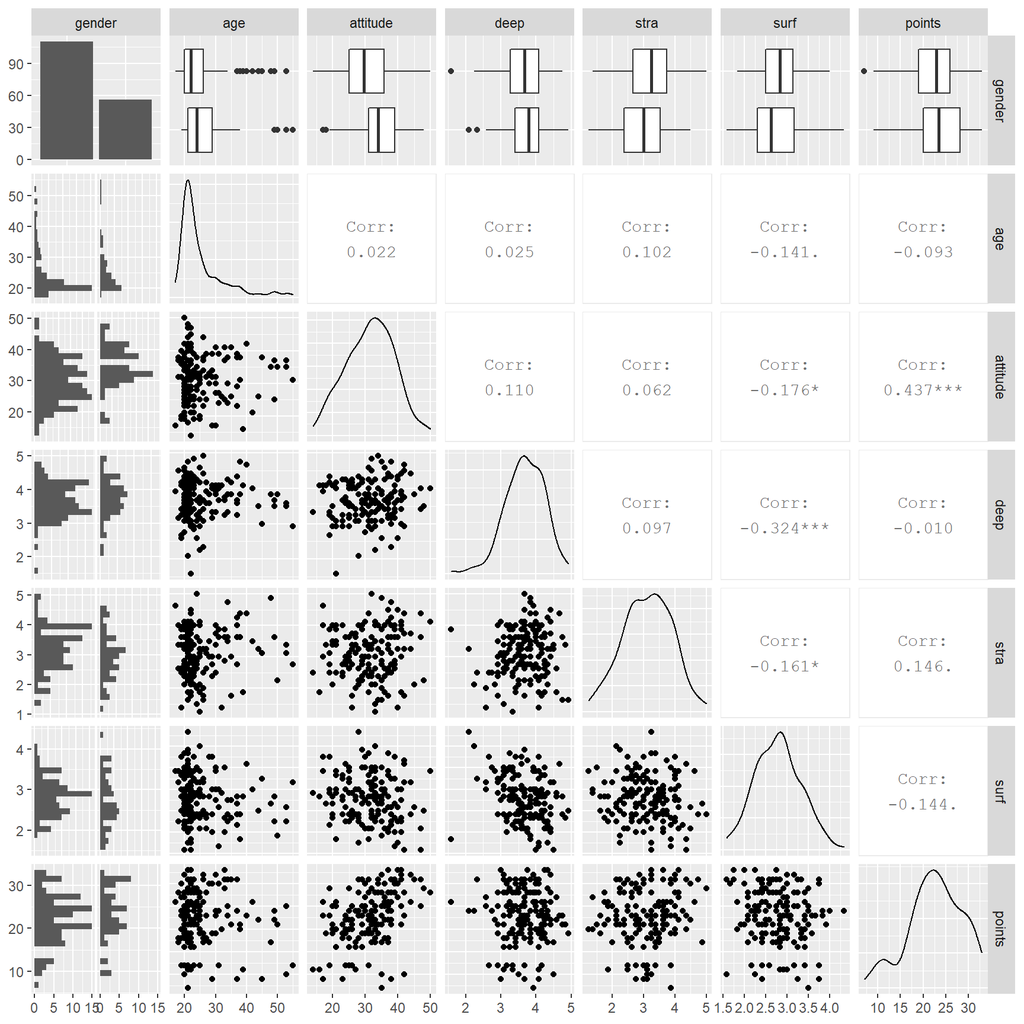

First note that genderwise two thirds of the students were female and one third male. Interestingly, while the males scored higher on attitude, both genders achieved very close to the same mean in the exam points. The majority of students are around 22 years old, but students of +50 years of age also participated in the course.

As one would expect, attitude has a notable correlation with the scored exam points. In terms of the learning approaches, surface-level learning negatively correlates with the points, which makes sense. Likewise, strategic learning approach tends to lead to higher score. However one might have expected deep level learning to have higher correlation with the exam points. Surface level and deep level learning approaches are opposite to each other, so they have some negative correlation.

### Regression model

In order to fit a linear regression model to predict the exam points of a student, we need to choose explanatory variables from the available features. Looking at how the other features correlate with the points, natural choices for the explanatory variables would be *attitude*, *stra*, and *surf*, as they have the highest absolute values for the linear correlation. The first two have positive correlation with the points, while the last one has negative.

Fitting the model gives us:

```
##
## Call:
## lm(formula = points ~ attitude + stra + surf, data = learning2014)
##
## Residuals:
##      Min       1Q   Median       3Q      Max
## -17.1550  -3.4346   0.5156   3.6401  10.8952
##
## Coefficients:
##             Estimate Std. Error t value Pr(>|t|)
## (Intercept) 11.01711    3.68375   2.991  0.00322 **
## attitude     0.33952    0.05741   5.913 1.93e-08 ***
## stra         0.85313    0.54159   1.575  0.11716
## surf        -0.58607    0.80138  -0.731  0.46563
## ---
## Signif. codes:  0 '***' 0.001 '**' 0.01 '*' 0.05 '.' 0.1 ' ' 1
##
## Residual standard error: 5.296 on 162 degrees of freedom
## Multiple R-squared:  0.2074, Adjusted R-squared:  0.1927
## F-statistic: 14.13 on 3 and 162 DF,  p-value: 3.156e-08
```

Let us however see what we get if *surf* is removed and the model is fitted only to *attitude* and *stra*.

```
##
## Call:
## lm(formula = points ~ attitude + stra, data = learning2014)
##
## Residuals:
##      Min       1Q   Median       3Q      Max
## -17.6436  -3.3113   0.5575   3.7928  10.9295
##
## Coefficients:
##             Estimate Std. Error t value Pr(>|t|)
## (Intercept)  8.97290    2.39591   3.745  0.00025 ***
## attitude     0.34658    0.05652   6.132 6.31e-09 ***
## stra         0.91365    0.53447   1.709  0.08927 .
## ---
## Signif. codes:  0 '***' 0.001 '**' 0.01 '*' 0.05 '.' 0.1 ' ' 1
##
## Residual standard error: 5.289 on 163 degrees of freedom
## Multiple R-squared:  0.2048, Adjusted R-squared:  0.1951
## F-statistic: 20.99 on 2 and 163 DF,  p-value: 7.734e-09
```

Now the equation is
$$points = 0.35 * attitude + 0.91 * stra + 8.97.$$

In order to compare these two models, consider the multiple R-squared values. It is a measure of how well the model fits the data. At a quick glance, the first model has higher multiple R-squared value of 0.2074, while the latter has 0.2048. However, it needs to be taken into account that the more variables a model has, the higher the R-squared value will be. So in fact we need to look at the adjusted R-squared value, which also considers the number of variables. The second model has higher adjusted R-squared value of 0.1951 compared to the value 0.1927 of the first model. While there isn’t a huge difference, the second model may be slightly more accurate predictor.

Next it is worth to evaluate the validity of the model. First recall three key assumptions:

1. The model is a linear combination of the explanatory variables
2. The errors of the model follow uncorrelated normal distributions
3. The errors have constant variance, which implies that the error size is independent of the variable values

It is possible to examine how well these assumptions hold with a few diagnostic plots:

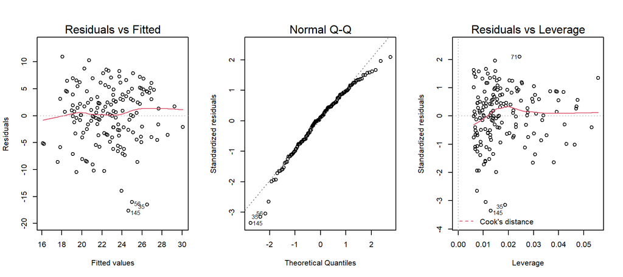

The left plot shows the residuals versus the fitted values. If any sort of structure is seen in the scatter plot, then the errors would be correlated to the variable values. This is also related to the linearity of the model, as strong non-linear structures in the plot would indicate that the model should also be non-linear. There is no notable structure in this plot, which means that the assumptions 1. and 3. hold fine.

The normal Q-Q plot in the middle shows whether the errors are normally distributed. Since the majority of the points in the plot follow the fitted line quite well, it can be concluded that the errors are can be approximated as normally distributed, and hence the assumption 2. also holds pretty good.

Finally the plot on the right shows the residuals versus leverage. It displays how strong of an effect single data points have on the fit. There are no points in the plot with highly significant leverage, which implies that there are no notable outliers and most of the points lie quite well around the fitted model.

# Week 3: Logistic Regression

The data set that is examined this week contains information about 382 Portuguese students at the secondary education level. This data set can be downloaded from [here](http://s3.amazonaws.com/assets.datacamp.com/production/course_2218/datasets/alc.txt) (which was wrangled from two data sets available [here](https://archive.ics.uci.edu/ml/datasets/Student+Performance)). For each student, there are 35 attributes:

```
##  [1] "school"     "sex"        "age"        "address"    "famsize"
##  [6] "Pstatus"    "Medu"       "Fedu"       "Mjob"       "Fjob"
## [11] "reason"     "nursery"    "internet"   "guardian"   "traveltime"
## [16] "studytime"  "failures"   "schoolsup"  "famsup"     "paid"
## [21] "activities" "higher"     "romantic"   "famrel"     "freetime"
## [26] "goout"      "Dalc"       "Walc"       "health"     "absences"
## [31] "G1"         "G2"         "G3"         "alc_use"    "high_use"
```

The attributes contain information about the students’ social background, demographics, activities, school performance level (combined from two subjects: Portuguese and Mathematics) and alcohol consumption. We are especially interested in how alcohol consumption relates to the other features. There are 114 out of the 382 students who are considered to have high alcohol consumption.

Before digging in the data, consider a few variables, which could be related to the amount of alcohol consumption.

- **Absences:** It is easy to conceive that there is likely to be a link between high alcohol consumption and being more absent from school.
- **Study time:** Consuming a lot of alcohol also consumes time, which means that the amount of time spent on studying is likely to be lower for those with high alcohol consumption.
- **Past class failures:** A history of high alcohol consumption should leave its mark on having failed classes in the past. On the other hand, if the studies are not going as planned, it might also lead a student to consume more alcohol.
- **Family relations:** Alcohol is never good for any relationships in the long term (and bad relations can also lead to alcoholism), so I would suspect that the quality of family relations for those with high alcohol consumption is lower than average.

To see whether there really is a relation between high alcohol consumption and the four variables I highlighted, it is best to have a look at the relevant plots.

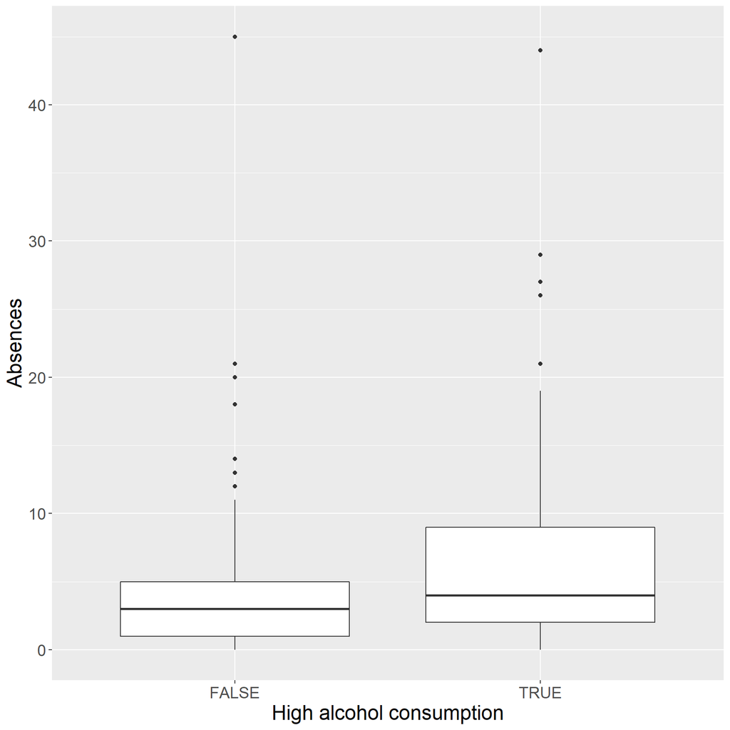

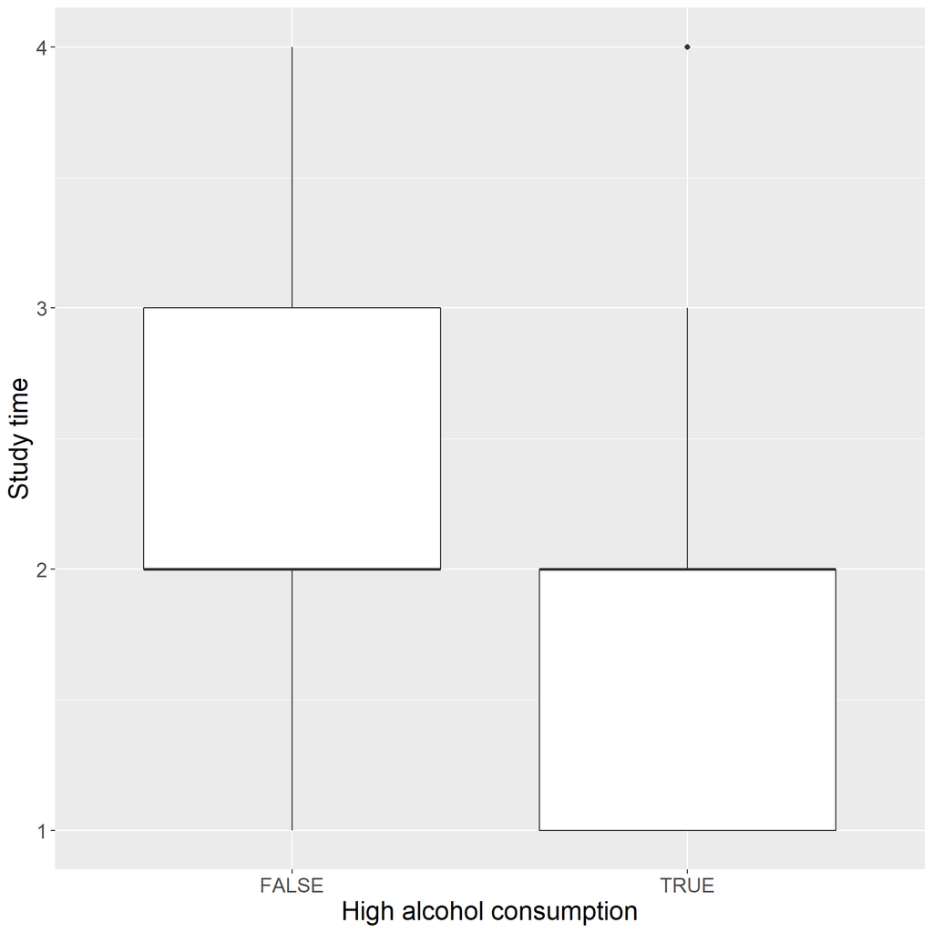

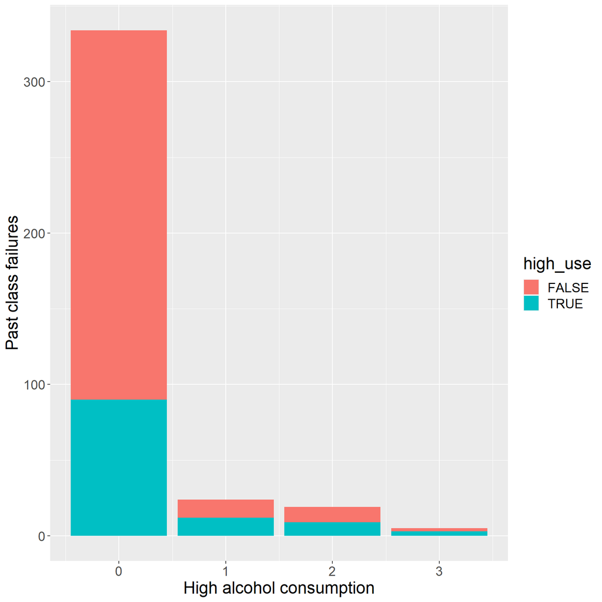

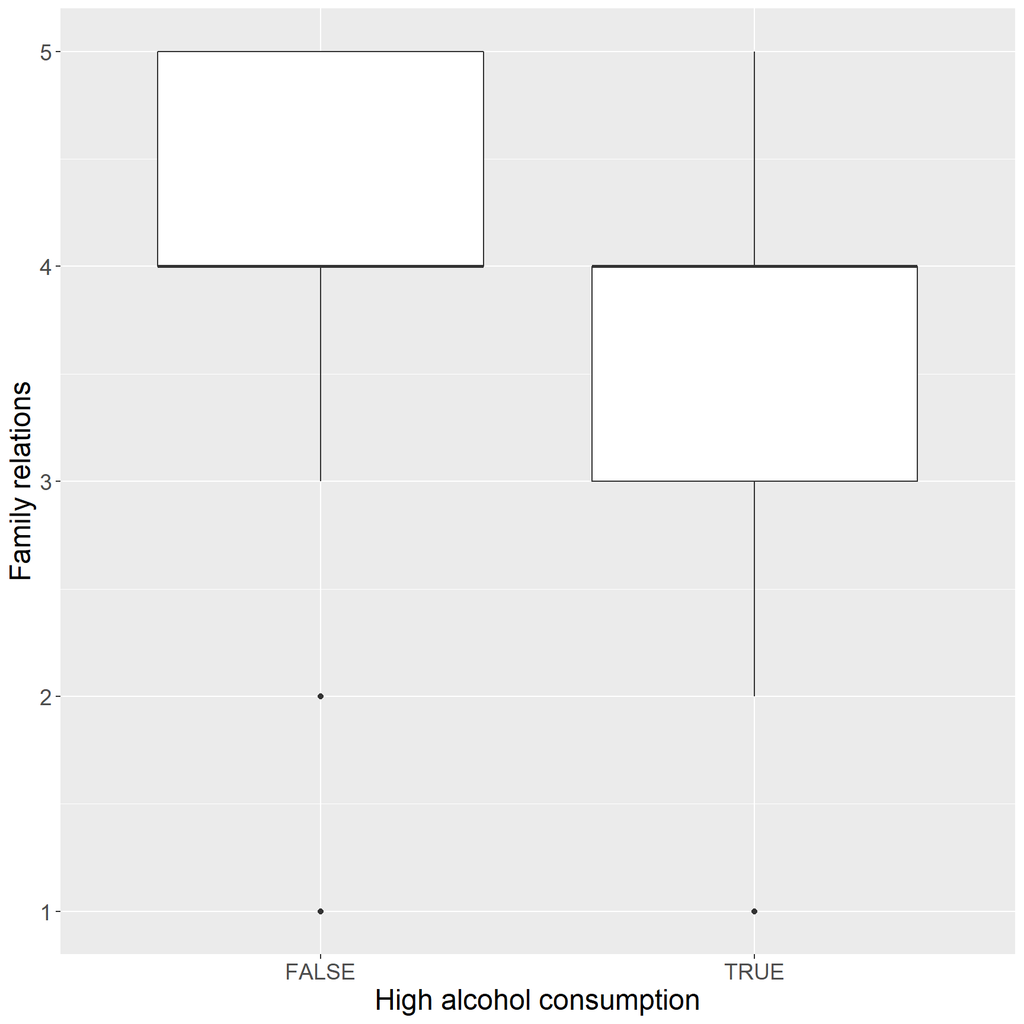

These plots support the hypotheses I stated earlier. High alcohol consumption leads to higher number of absences and lower study time. There is also a relation between high alcohol consumption and past class failures. While less than one third of the total number of students are considered to have high alcohol consumption, they make up about half of the students with one or more past class failures. The family relations are also on average lower among those students.

### Regression model

The relationship between these features and high alcohol consumption can be further examined with a logistic regression model, that tries to predict whether or not a student has high alcohol consumption based on the features.

```
##
## Call:
## glm(formula = high_use ~ absences + studytime + failures + famrel,
##     family = "binomial", data = alc)
##
## Deviance Residuals:
##     Min       1Q   Median       3Q      Max
## -2.1020  -0.8046  -0.6356   1.0929   2.1626
##
## Coefficients:
##             Estimate Std. Error z value Pr(>|z|)
## (Intercept)  0.51942    0.61298   0.847 0.396787
## absences     0.07646    0.02237   3.417 0.000632 ***
## studytime   -0.48275    0.15859  -3.044 0.002335 **
## failures     0.34535    0.18900   1.827 0.067659 .
## famrel      -0.22547    0.12713  -1.773 0.076149 .
## ---
## Signif. codes:  0 '***' 0.001 '**' 0.01 '*' 0.05 '.' 0.1 ' ' 1
##
## (Dispersion parameter for binomial family taken to be 1)
##
##     Null deviance: 465.68  on 381  degrees of freedom
## Residual deviance: 426.85  on 377  degrees of freedom
## AIC: 436.85
##
## Number of Fisher Scoring iterations: 4
```

The coefficients of the model can be interpreted as odds ratios. Let’s check these ratios and their confidence intervals.

```
##             odds_ratios     2.5 %    97.5 %
## (Intercept)   1.6810604 0.5041644 5.6209355
## absences      1.0794604 1.0353405 1.1306057
## studytime     0.6170848 0.4480057 0.8355182
## failures      1.4124849 0.9753615 2.0584625
## famrel        0.7981401 0.6215738 1.0249848
```

Unfortunately I didn’t quite have enough time to further evaluate the predictive power of the model.